# Recursive Functions

- Function that calls itself
- Function must have an exit condition, so it will know when to stop

## Recursion 1

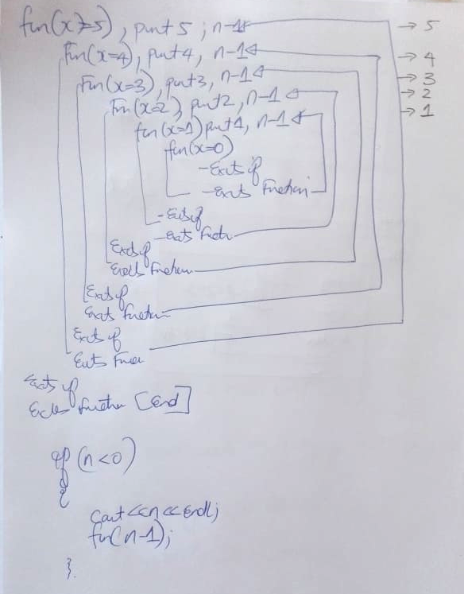

## How does it work

With any **Recursuve** function, there must be a exit condition so the program will know whne to stop.

```
In our case that is:
if (n>0)
{
 ...
}
```

So fun get called with value (5) from the main program, checks if n > 0, then print out the value (5), and then call itself, repeats this process until, n >0. When n = 0, the function exits. But exits the amout of time it was called.

Procudure (for this one):

**Here output to be printed or action to be completed BEFOREHAND, and nothing happens when exit function is reached.**

```
if (n>0)
{
  cout<<n<<endl;
  fun(n-1)
}
```

[output not shown]

```
fun (5) n=5, prints 5, n-1
fun (4) n=4, prints 4, n-1
fun (3) n=3, prints 3, n-1
fun (2) n=2, prints 2, n-1
fun (1) n=1, prints 1, n-1
fun (0):
    Exits fun, where n = 0
    Rolls back 5 times, what happens inside if
    Completes rest code AFTER fun
        Rolls back 5 times
        n=1,n=2,n=3,n=4,n=5
        When n = 5, exits the last fun
```

```python
#include <iostream>
#include <climits>
#include <math.h>
using namespace std;
```

```python
void fun(int n ){
    if (n>0)
    {
      cout<<n<<endl;
      fun(n-1);
    }
}
```

```python
int x = 5;
fun(x);
```

```
5
4
3
2
1
```

## Recursion 2

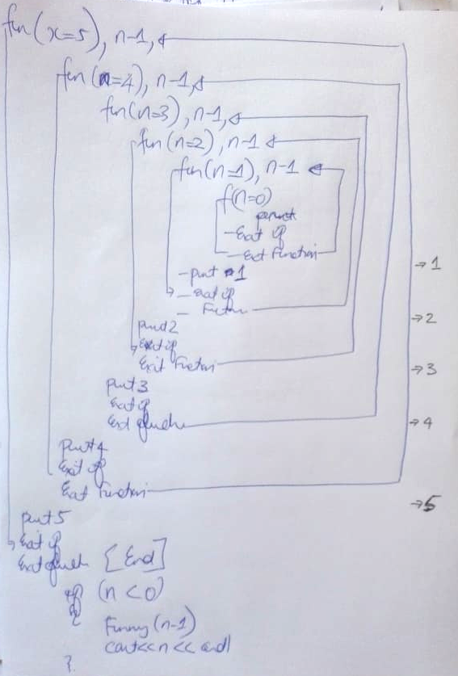

## How does it work

With any **Recursuve** function, there must be a exit condition so the program will know whne to stop.

```
In our case that is:
if (n>0)
{
 ...
}
```

Procudure (for this one):

**Here output to be printed or action to be completed is delayed, until exit function is reached.**

```
if (n>0)
{
  fun(n-1)
  cout<<n<<endl;
}
```

[output not shown]

```
fun (5) n=5, n-1
fun (4) n=4, n-1
fun (3) n=3, n-1
fun (2) n=2, n-1
fun (1) n=1, n-1
fun (0):
   Exits fun, where n = 0
   Rolls back 5 times, what happens inside if
   Completes rest code AFTER fun
        n=1, print 1, exits if, exit fun
        n=2, print 2, exits if, exit fun
        n=3, print 3, exits if, exit fun
        n=4, print 4, exits if, exit fun
        n=5, print 5, exits if, exit last fun,  end
```

| Rollback value of n | Printed AFTER fun | Exits if | Exits Fun |
| --- | --- | --- | --- |
| n=1 | prints 1 | Yes | Yes |
| n=2 | prints 2 | Yes | Yes |
| n=3 | prints 3 | Yes | Yes |
| n=4 | prints 4 | Yes | Yes |
| n=5 | prints 5 | Yes | Yes |

```python
void funny(int n ){
    if (n>0)
    {
      funny(n-1);
      cout<<n<<endl;
    }
}
```

```python
funny(x);
```

```
1
2
3
4
5
```